[figure not shown]

# LoCP (mod.B) Final Project

# Study of an upper bound of $\mathcal{B}(H \longrightarrow J/\psi \gamma)$ in $pp$ collisions at $\sqrt{s} = 13 \ \text{TeV}$

### Authors

- [**Ardino Rocco**](https://github.com/RoccoA97) (University of Padua)
- [**Paccagnella Andrea**](https://github.com/pacca4) (University of Padua)
- [**Valente Alessandro**](https://github.com/mastrovalentz) (University of Padua)

### Supervisors

- Prof. [**Marco Zanetti**](https://github.com/mzanetti79) (University of Padova, CERN)
- Dr. [**Alberto Zucchetta**](https://github.com/zucchett) (University of Padova, CERN)

### Index

1. **Introduction**
   - 1.1. **Project context and goals**
   - 1.2. **Software and needed packages**
2. **The datasets**
   - 2.1. **Background dataset**
   - 2.2. **Signal dataset**
3. **Slim, Skim, Selection and Cut operations for background reduction**
   - 3.1. **Slimming, Skimming, Selection and first Cut through postprocessor**
   - 3.2. **Precision cuts**
4. **Fit of background and signal distributions**
   - 4.1. **Fit of background distribution**
   - 4.2. **Fit of signal distribution**
5. **Toy Monte Carlo analysis**
   - 5.1. **Definition of the test statistic**
   - 5.2. **Definition of the algorithm**
   - 5.3. **Validation of the algorithm for $\mu=0$**
   - 5.4. **Results as a function of $\mu$**
6. **Conclusions**

## 1. - Introduction

- Index

### 1.1. - Project context and goals

- Index

#### **Physics context**

In 2012, a new boson with a mass of $125 \ \text{GeV}$ was observed in data from the ATLAS and CMS experiments at the CERN LHC. All measurements of the properties of this boson are consistent with those of the Higgs boson ($H$) of the standard model (SM). However, the Yukawa couplings of the Higgs boson to the first- and second-generation quarks are currently only weakly constrained. Rare exclusive decays of the Higgs boson to mesons in association with a photon can be used to explore such couplings. For example, the decay:

$$ H \longrightarrow J/\psi \gamma $$

can probe the Higgs boson coupling to the charm quark. Through CMS detector, a study can be done by considering the subsequent decay of the $J/\psi$ to $\mu^+\mu^-$, which has a SM predicted branching ratio of:

$$ \mathcal{B}(H \rightarrow J/\psi\gamma \rightarrow \mu^+\mu^-\gamma) = \mathcal{B}(H \rightarrow J/\psi\gamma) \cdot \mathcal{B}(J/\psi \rightarrow \mu^+\mu^-) = 3.0 \cdot 10^{-6} \cdot 5.9 \cdot 10^{-2} \approx 1.8 \cdot 10^{-7} $$

This information, combined with the Higgs cross section $\sigma_H$ and with the total integrated luminosity $\mathcal{L}$ of LCH, gives an expected number of events of about $1.22$ over 3 years of runs. So, this is quite difficult to observe, but an exclusion upper limit for the branching ratio can be studied through filtering and Monte Carlo techniques.

#### **Goals**

In this project, we consider the **NanoAOD SingleMuon** datasets of CMS from 2016, 2017 and 2018 runs (for the background) and a Monte Carlo simulated dataset of $H \rightarrow J/\psi \rightarrow \mu^+\mu^-\gamma$ (for the signal). Our aims are:

- **finding an optimal cut** applied to both the datasets in order to filter the background data but at the same time keeping a good fraction of signal events;
- **modeling** the filtered background and signal distributions;
- **applying a Monte Carlo statistical analysis** to the background plus signal distribution amplified by a factor $\mu$, namely the signal strength parameter;
- **finding a significance** of signal detection depending on $\mu$, from which we extract the upper limit on the branching ratio.

### 1.2. - Software and needed packages

- Index

The whole analysis has been performed on the **ROOT** analysis framework, in particular this was done using the [**CMS Tools**](https://github.com/cms-nanoAOD/nanoAOD-tools) in the first part and implementing several macros in **c++ language** and some **bash scripts** to automate the workflow in the latter. The source code can be found [**here**](https://github.com/pacca4/Project_LocpB_plots).

Here, we import all the needed python and PyROOT packages for the report.

#### **Python packages**

```python
import numpy as np
import matplotlib.pyplot as plt
import matplotlib.image as mpimg
import scipy as sp
```

```python
from scipy.stats import chi2, chisquare
```

#### **PyROOT packages**

```python
import ROOT
```

```
Welcome to JupyROOT 6.18/04
```

```python
from ROOT import TFile
from ROOT import TCanvas, TLegend, TLatex
from ROOT import gRandom, gPad, gROOT, gStyle
from ROOT import kTRUE, kGreen, kRed, kBlue
```

#### **JSROOT on/off**

```python
JSROOT = True
```

```python
%%javascript
if (!0) {
    var s = document.createElement('script');
    s.src='https://cdnjs.cloudflare.com/ajax/libs/require.js/2.3.6/require.min.js';
    document.body.appendChild(s);
}
```

```python
if JSROOT:
    %jsroot on
```

## 2. - The datasets

- Index

For our analysis, we employ two datasets, one for background data and one for signal. The latter is simulated through Monte Carlo generation software like MadGraph5, taking into account the hadronization and the detector response through other sotwares like Pythia and Delphi.

### 2.1. - Background dataset

- Index

The background dataset is the collection of the **NanoAOD** files belonging to the **SingleMuon list**. It contains the filtered data from CMS experiment collected from the runs from 2016 to 2018. Note that the NanoAOD format comes from the last part of pre-selection events and its weigth is of the order of **~1 kB/event**. This is very small compared to the weigth of about ~1 MB/event of raw data coming from the trigger.

### 2.2. - Signal dataset

- Index

The signal dataset is a Monte Carlo simulation of the decay $H \longrightarrow J/\psi \gamma$, coming as well as the background files in the NanoAOD format.

## 3. - Slim, Skim, Selection and Cut operations for background reduction

- Index

Since the number of background events is too huge for our purpose, the first part of our work is reducing this dataset through several operations:

- **Slimming**: we are interested only in certain physical features and triggers inside the background files, so we keep only the branches useful for the following analysis and for reconstructing some other interesting features. All the rest is not kept.
- **Skimming**: not all the events are interesting for our analysis, in particular the ones which do not satisfy a certain condition on the luminosity during their collection. In the new slimmed and skimmed files, these events will not be present.
- **Selection**: as before, there are some conditions that signal events should meet. Some of them are condensed inside the High Level Triggers (HLTs), which are substantially a bool that is `true` if a characteristic condition is met, otherwise it flags `false`.
- **Cutting**: a candidate signal is characterized by certain kinematic conditions. Therefore, some upper and/or lower bounds on some kinematic features have to be set. The events which do not meet these conditions will not be considered.

In the following subsections, we explain in a deeper way this procedure and we present its results.

### 3.1. - Slimming, Skimming, Selection and first Cut through postprocessor

- Index

In the first part of background data reduction, we perform several operations for event selection based on:

- the actual luminosity during the acquisition;
- the presence of at least 2 muons and a photon;
- a trigger bool variable;
- raw cuts on kinematic variables.

Therefore, the first thing the events must satisfy is to belong to one of the optimal luminosity blocks. This information is stored in several JSON formatted text files. The remaining events are required to have at least 2 muons and a photon and to satisfy the trigger condition. Since the dataset we are employing is the **SingleMuon** dataset, a good trigger choice is the **`HLT_IsoMu27`**, whose acceptance computed on Monte Carlo dataset is 58.8%. Then, the surviving events must satisfy the following kinematic conditions:

- $\color{green}{m_{\mu\mu\gamma}\in[70, 150] \ \text{GeV}/c^2}$, where $m_{\mu\mu\gamma}$ is the $\mu\mu\gamma$ invariant mass;
- $\color{green}{m_{\mu\mu}\in [2.9, 3.3] \ \text{GeV}/c^2}$, where $m_{\mu\mu}$ is the $\mu\mu$ invariant mass;
- $\color{green}{p_{T,\mu_1}>27 \ \text{GeV}/c}$, where $p_{T,\mu_1}$ is the leading muon transverse momementum;
- $\color{green}{p_{T,\gamma}>25 \ \text{GeV}/c}$, where $p_{T,\gamma}$ is the photon transverse momementum.
- $\color{green}{\eta_{\mu_1}<2.4}$, where $\eta_{\mu_1}$ is the leading muon pseudorapidity.
- $\color{green}{\eta_{\mu_2}<2.4}$, where $\eta_{\mu_2}$ is the subleading muon pseudorapidity.
- $\color{green}{\eta_{\gamma}<2.5}$, where $\eta_{\gamma}$ is the photon pseudorapidity.
- $\color{green}{\texttt{Muon_looseId[0]==True}}$, which translates into a good reconstruction of the leading muon.
- $\color{green}{\texttt{Muon_looseId[1]==True}}$, which translates into a good reconstruction of the subleading muon.

By this way, we obtain a smaller dataset, deleting lots of events which do not belong to our case study.

Although in the slimming operation we remove several branches from root files, it is convenient for the following analysis to add new branches to store useful observables for signal over background discrimination when we monitorate the difference from Monte Carlo simulated dataset.

The new main physical observables computed are:

- **`JPsi_mass`**: the reconstructed mass of the candidate $J/\psi$;
- **`JPsi_pt`**: the transverse momentum $p_T$ of the candidate $J/\psi$;
- **`JPsi_eta`**: the pseudorapidity $\eta$ of the candidate $J/\psi$;
- **`JPsi_phi`**: the azimuthal angle $\phi$ of the candidate $J/\psi$;
- **`Reco_mass`**: the reconstructed mass of the candidate $H$;
- **`Reco_pt`**: the transverse momentum $p_T$ of the candidate $H$;
- **`Reco_eta`**: the pseudorapidity $\eta$ of the candidate $H$;
- **`Reco_phi`**: the azimuthal angle $\phi$ of the candidate $H$.

Some other classes of features are added for further analysis, where we perform precision cuts:

- **`DeltaR`**: the $\Delta R$ between two particles, defined as:

  $$ \Delta R = \sqrt{(\Delta\phi)^2+(\Delta\eta)^2} $$
- **`AngleCM`**: the cosine angle between two particles in the center of mass frame, computed as:

  $$ \cos\theta = \frac{\vec{v_1}^*\cdot\vec{v_2^*}} {|\vec{v_1^*}|\cdot|\vec{v_2^*}|} $$
- **`DeltaEtaCM`**: the difference of pseudorapidity $\eta$ between two particles in the center of mass frame;
- **`DeltaPhiCM`**: the $\phi$ angle between two particles in the center of mass frame;
- **`DeltaRCM`**: the $\Delta R$ between two particles in the center of mass frame.

The angular variables are computed by boosting the particles momenta to the center of mass frame of the reconstructed particles. In the reference frame the $\Delta R$, $\Delta \phi$ and $\Delta \eta$ are computed alongside with the angle between the tracks.

All these operations are performed by implementing a python class called **postprocessor**, where all the manipulations on the root files are inserted. In particular, this class is instantiated inside a python CMS script, which takes also the JSON files for the optimal luminosity blocks.

```python
%run -i 'macros/plot_skimmed.py'
```

[output not shown]

### 3.2. - Precision cuts

- Index

From this plots, we are able to decide which can be reasonable further cuts to apply:

- $\color{green}{p_{T,\mu_1}>28 \ \text{GeV}/c}$;
- $\color{green}{\texttt{Muon_pfRelIso03_all[0]}<0.15}$.
- $\color{green}{\texttt{Muon_pfRelIso03_all[1]}<0.15}$.
- $\color{green}{\texttt{Photon_pfRelIso03_all[0]}<0.15}$.

Moreover, we also require a sufficiently good reconstruction of the photon, so we also apply the following condition:

- $\color{green}{\texttt{Photon_mvaID_WP80[0]==True}}$.

With these requirements we obtain an **overall acceptance** on the Monte Carlo dataset of **21.1%**.

## 4. - Fit of background and signal distributions

- Index

Once the quality cuts and the trigger selection have been applied, we get two different datasets, one for the Monte Carlo signal and one for the background. In order to perform a statistical analysis, it is fundamental to model the invariant mass spectrum distribution for all the datasets. In this section, we try to accomplish this task by employing **RooFit**, but at the same time we try to avoid too complex models since they would require a higher computational effort for the final Monte Carlo analysis.

### 4.1. - Background distribution

- Index

```python
%run -i "macros/plot_Reco_mass_bkg.py"
```

[output not shown]

Taken into account the invariant mass trend in the previous plot, we decide to fit the distribution using an **exponential PDF**. The fit is performed using the Maximum Likelihood Estimation method over the binned dataset. Moreover, it is important to notice that, in order to avoid bias for future predictions, the fit was performed while being **"blind" in the signal region**.

```python
%run -i "macros/plot_fit_bkg.py"
```

[output not shown]

```
RooFit v3.60 -- Developed by Wouter Verkerke and David Kirkby
                Copyright (C) 2000-2013 NIKHEF, University of California & Stanford University
                All rights reserved, please read http://roofit.sourceforge.net/license.txt
```

## 4.2. - Signal distribution

- Index

```python
%run -i "macros/plot_Reco_mass_sig.py"
```

[output not shown]

Differently from the background distributions, it is not possible to perform a fit for signal spectrum using a simple PDF, mainly due to the tails which are asymmetric.

The model used for the fit is then defined by summing more PDFs and applying some constraints. A good choice to take into account the asymmetry in the tails is to fit with a **Crystal Ball function**, which reads:

$$ f(x ; \alpha, n, \bar{x}, \sigma) = N \cdot \begin{cases} \exp \left(-\frac{(x-\bar{x})^{2}}{2 \sigma^{2}}\right), & \text { for } \frac{x-\bar{x}}{\sigma}>-\alpha \\ A \cdot\left(B-\frac{x-\bar{x}}{\sigma}\right)^{-n}, & \text { for } \frac{x-\bar{x}}{\sigma} \leqslant-\alpha \end{cases}$$

For the final PDF model, the Crystal Ball function is added to other **three Gaussian distributions** with a proper weight. Moreover, since we expect the mass resonance to have a precise value in the invariant mass spectrum, we then impose the center of the Gaussians to be at the same position of the Crystal Ball function peak.

This new model allows us to reproduce in an optimal way the form of the distribution. The final signal PDF reads:

$$ \mathcal{S}(m) = f_c \mathcal{CB}(m) + (1-f_c)\mathcal{G_S} $$

where $f_c$ is the weight of the Crystal Ball with respect to the sum of the three Gaussians $\mathcal{G_3}$ function, which reads:

$$ \mathcal{G_3}(m)= f_1\mathcal{G_1}(m)+(1-f_1)\left[ f_2\mathcal{G_2}(m) + (1-f_2)\mathcal{G_3}(m)\right] $$

where $f_{1,2}$ are proper weights.

```python
%run -i "macros/plot_fit_sig.py"
```

[output not shown]

## 5. - Toy Monte Carlo analysis

- Index

Now that we have cutted a large portion of background events and we have modeled the background and the signal distributions, we move to the last part of our analysis. We perform a toy Monte Carlo statistical analysis using as statistical test a log likelihood ratio, as it is done for the standard analysis at LHC, but with some differences.

### 5.1. - Definition of the test statistic

- Index

The first step is to define a statistical variable, whose distribution will be sampled for several $\mu$ values, each distribution defining a certain hypotesis $H_{\mu}$. This is the negative loglikelihood ratio, which reads:

$$ q(\mu) = - 2 \log \frac{\mathcal{L}(\mu;\hat{\sigma}(\mu))}{\mathcal{L}(\hat{\mu};\hat{\hat{\sigma}}(\hat{\mu}))} $$

The quantity on the numerator is the likelihood computed on the data with the best-fit parameters $\hat{\sigma}$ infered at fixed $\mu$. The quantity on the denominator is the maximum obtainable likelihood computed on the data. This is our starting point for the statistical analysis.

We will focus on the invariant mass spectrum of the candidate $H$, so when speaking about "data", we are implying that these are the measurements of $m_{\mu\mu\gamma}$. Another fact to take into account is that we have binned data. Therefore, the number of counts $n_i$ in the $i^{\text{th}}$ bin follows a Poisson distribution, whose characteristic parameter will be denoted with $\sigma_i$, which reads:

$$ \sigma_i = B_i + \mu S_i $$

where $B_i$ and $S_i$ are respectively the number of background and signal events in the $i^{\text{th}}$ bin.

### 5.2. - Definition of the algorithm

- Index

Taking into account what previously defined, we can express in a more clear way the test statistic expression for our toy Monte Carlo sampling algorithm:

$$ q(\mu) = - 2 \log \frac{\mathcal{L}(\mu;\hat{\sigma}(\mu))}{\mathcal{L}(\hat{\mu};\hat{\hat{\sigma}}(\hat{\mu}))} = - 2 \log \frac{\displaystyle \prod_{n_i \in \text{bin}_i} \frac{{\hat{\sigma}_i}^{n_i}}{n_i!} e^{-\hat{\sigma}_i}}{\displaystyle \prod_{n_i \in \text{bin}_i} \frac{{n_i}^{n_i}}{n_i!} e^{-n_i}} = - 2 \log \prod_{n_i \in \text{bin}_i} \left( \frac{\hat{\sigma}_i}{n_i} \right)^{n_i} e^{-\hat{\sigma}_i + n_i} = - 2 \sum_{n_i \in \text{bin}_i} \left[ n_i \log\left( \frac{\hat{\sigma}_i}{n_i} \right) -\hat{\sigma}_i + n_i \right] $$

In order to sample $q(\mu)$ for a certain value of $\mu$, we apply a toy Monte Carlo study. A single toy produces a single value of $q(\mu)$ with the following steps:

- the signal distribution is added to the background distribution after a proper rescaling based on the luminosity, the cross section and the number of signal events in the MC simulated signal;
- the rescaled signal distribution summed to the background distribution is amplified by a factor $\mu$;
- a number of events compatible with the residual background and the expected signal events is generated through Monte Carlo simulation;
- the generated toy dataset is put into a histogram with a fixed number of bins $n^{\text{ToyMC}}_{\text{bins}}$;
- this simulated and binned spectrum is fitted again, but only with the background distribution (here comes the difference with the standard LHC procedure);
- the background fit is employed to compute the $q(\mu)$ defined before, with the $\hat{\sigma}_i$ for every bin calculated through the fit function.

This algorithm is repeated for a large number of times to have a smooth sampled distribution for $H_{\mu}$.

### 5.3. - Validation of the algorithm for $\mu=0$

- Index

Before presenting the results for a scan in a $\mu$ range, it is necessary to check if the test statistic is solid and valid. So, we focus in this subsection on the case of $\mu=0$, in which the background distribution coincides with the signal plus background distribution.

From **Wilks's theorem**, we know that this test statistic for $H_0$ follows asymptotically a $\chi^2$ distribution with a number of degrees of freedom equal to the number of bins $n^{\text{ToyMC}}_{\text{bins}}$ minus the number of background fit parameters, so a **18 dofs $\chi^2$ distribution**. We check in the following cells if this expectation is met by comparing the toy Monte Carlo sampled distribution of $q(\mu=0)$ with a $\chi^2(\nu)$ distribution.

```python
nsamp      = 100000
nbins      =     20
mu         =      0
nev_IsoMu  =   1000

fname_IsoMu = 'ToyMC_BatchMu_SingleMuon__nsamples_' +str(nsamp)+'__nbins_'+str(nbins)+'__nev_'+str(nev_IsoMu) +'__mu_'+str(mu)+'.0.txt'
dir_IsoMu   = "./mc_samples/ToyMC_BatchMu_SingleMuon__nsamples_" +str(nsamp)+"__nbins_"+str(nbins)+"__nev_"+str(nev_IsoMu) +"/"

data_mu_0_IsoMu = np.loadtxt(dir_IsoMu + fname_IsoMu)
```

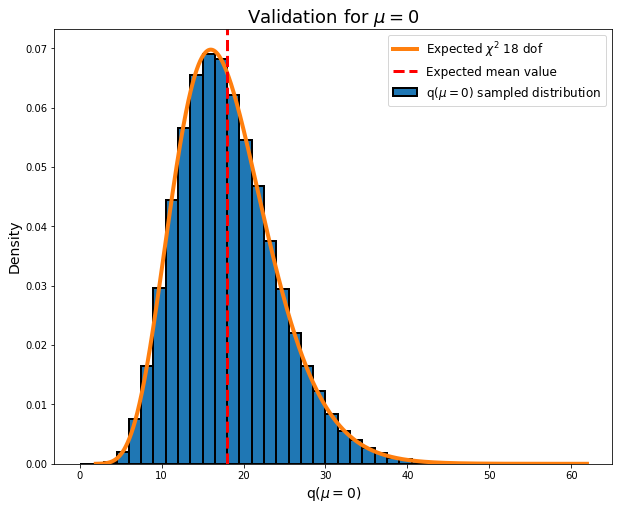

```python
nb   =  40
xmin =   0
xmax =  60
plt.figure(figsize=(10, 8))

dof_IsoMu   = 18
med0_IsoMu  = np.median(data_mu_0_IsoMu )

x_IsoMu  = np.linspace(chi2.ppf(0.000001,dof_IsoMu ), chi2.ppf(0.999999,dof_IsoMu ), 10000)

plt.hist(data_mu_0_IsoMu,  bins=nb, edgecolor='black', linewidth=2, range=(xmin, xmax), density=True, label="q($\mu=0$) sampled distribution")
plt.plot(x_IsoMu,  chi2.pdf(x_IsoMu,  dof_IsoMu ), '-', lw=4, alpha=1, label="Expected $\chi^2$ "+str(dof_IsoMu )+" dof")
plt.axvline(dof_IsoMu,  c='r', ls='--', lw=3, label="Expected mean value")
plt.xlabel("q($\mu=0$)", fontsize=14)
plt.ylabel("Density", fontsize=14)
plt.title("Validation for $\mu=0$",  fontsize=18)
plt.legend(fontsize=12)

plt.show()
```

### 5.4. - Results as a function of $\mu$

- Index

Now, we move to the analysis of $q(\mu)$ distribution for $\mu \neq 0$ and we introduce the algorithm employed for extracting the statistical results from the toy Monte Carlo sampling.

We want to translate the discrepancy between the $H_0$ and $H_{\mu}$ distributions in statistical terms. After having checked that the $H_0$ follows the expected distribution, we can evaluate a $p$-value on it for a given $H_{\mu}$, but we have to define the bounds of the integral through which the $p$-value is computed. More precisely, the definition of the $p$-value reads:

$$ p(\mu) = \int_{\xi}^{+\infty} \chi^2(q; \nu) \ \text{d}q $$

The lower bound $\xi$ in the previous equation should be extracted from the $H_{\mu}$ distribution by calculating a meaningful statistical quantity. A reasonable possibility is the median $q_{\text{med}}(\mu)$, since it allows an easier comparison with an eventual ideal significance value. Therefore, the previous equation reads:

$$ p_{\text{med}}(\mu) = \int_{q_{\text{med}}(\mu)}^{+\infty} \chi^2(q; \nu) \ \text{d}q $$

where $p_{\text{med}}(\mu)$ is the median $p$-value computed through the median $q(\mu)$ of the distribution $H_{\mu}$. From this quantity, we can retrieve a median significance from a one-tail comparison with a normal distribution:

$$ \sigma_{\text{med}}(\mu) = \sqrt{2} \cdot \text{erf}^{-1}(1 - p_{\text{med}}(\mu)) $$

In the following cells, we present the results for **`SingleMuon`** dataset, obtaining an upper limit for $\mu$ at a 95% CL.

#### **Results for `SingleMuon` dataset**

Firstly, we perform a coarse scan over the various results for several values of $\mu$.

```python
%run -i 'macros/LoadIsoMu.py'
%run -i 'macros/finalPlots.py'
```

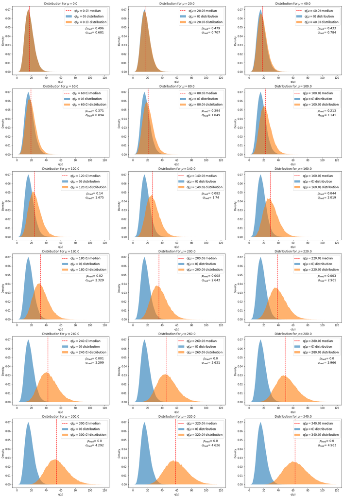

```python
nr = 6
nc = 3
fig, axs = plt.subplots(nr, nc, figsize=(8*nc, 6*nr))
for i in range(0,nr):
    for j in range(0,nc):
        sub_plot_hists(axs[i,j], 100, 10*(j+nc*i), ndf=18)
```

From the previous plots, we find an interval for $\mu$ inside which the median significance reaches a value of 2 $\sigma$ equivalent. So, we perform a finer scan inside this region.

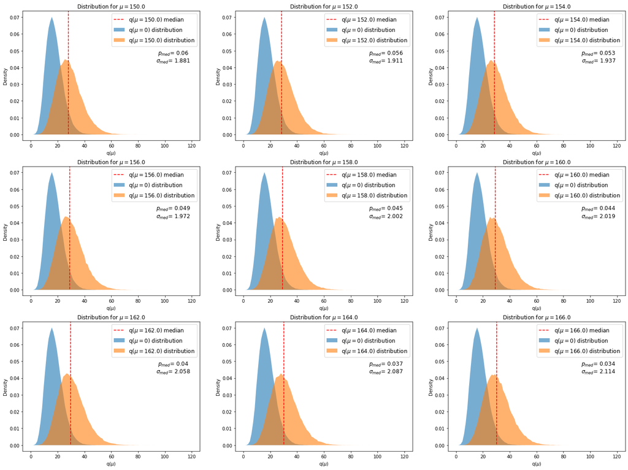

```python
nr = 3
nc = 3
fig, axs = plt.subplots(nr, nc, figsize=(8*nc, 6*nr))
for i in range(0,nr):
    for j in range(0,nc):
        sub_plot_hists(axs[i,j], 100, 75+(j+nc*i), ndf=18)
```

By this way, we find the upper limit for $\mu$ at a 95% CL for `SingleMuon` dataset. In the following cell, we plot the distribution $H_{\mu}$ depending on the value of $\mu$ and the median significance dependece on $\mu$ for the same dataset.

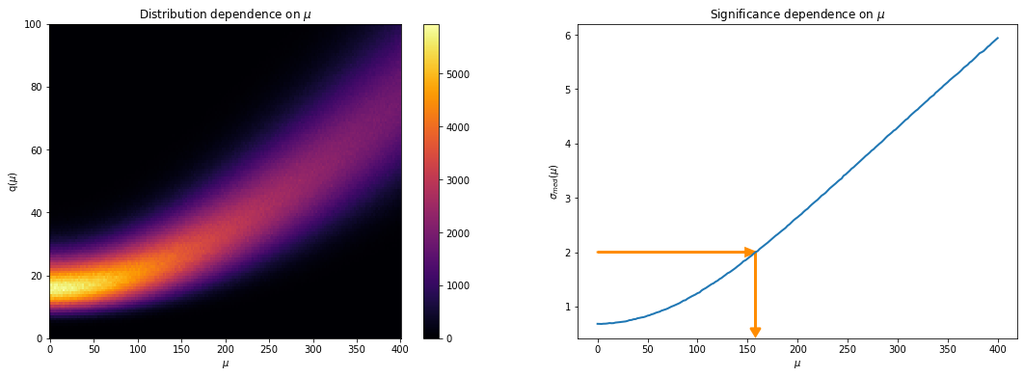

```python
sigs=[]
for i in np.linspace(0, 200, 201, dtype=np.int):
    sigs.append(significance(200, i, ndf=18)[1])

h_mu=[]
for i in range (0, nsamp):
    h_mu.append(mus)
h_mu= np.array(h_mu).T

final_mu_SingleMuon = plot_all_distr_SingleMuon(sigs, h_mu, plot_arrow=True, bound=2., ly=-1.55, hw1=0.15, hw2=10, hl1=10, hl2=0.15)
```

```python
print("Final mu bound for SingleMuon dataset: ", final_mu_SingleMuon)
```

```
Final mu bound for SingleMuon dataset:  157.86893425587104
```

**The final estimate for the upper bound of $\mu$ for `SingleMuon` dataset is:**

$$ \boxed{ \mu^{\texttt{SingleMuon}} \approx 160 } $$

## 6. - Conclusions

- Index

In this analysis we have studied the Higgs rare decay into $J/\psi \gamma$, followed by the decay of the $J/\psi$ into $\mu^+\mu^-$, in order to find an upper limit for the branching ratio of the decay channel. For this purpose, we have started from the huge background NanoAOD dataset of **SingleMuon**, collected by CMS experiment during 2016, 2017, 2018, and from a MC simulated dataset. After a significant reduction of background events through skim, skim, trigger selections and quality cuts, we have obtained a filtered dataset. Then, we have modeled its invariant mass spectrum distribution, as well as for the corresponding filtered signal dataset. The best-fit distributions have been employed for a toy Monte Carlo statistical analysis, from which we have extrapolated a **$\mu$ upper limit at 95% CL**:

$$ \boxed{ \mu^{\texttt{SingleMuon}} \approx 160 } $$

These value leads to an upper bound at 95% CL for $\mathcal{B}(H \longrightarrow J/\psi \gamma)$, in $pp$ collisions at $\sqrt{s} = 13 \ \text{TeV}$, equals to:

$$ \boxed{ \mathcal{B}^{\texttt{SingleMuon}}(H \longrightarrow J/\psi \gamma) \le \mu^{\texttt{SingleMuon}} \cdot \mathcal{B}(H \longrightarrow J/\psi \gamma) \approx 4.8 \cdot 10^{-4} } $$